# Laplacian matrix of a graph

Blake Baird

2/16/2022

## Problem

Let A be the incidence matrix of a directed graph with n nodes and m edges. The **Laplacian matrix** associated with the graph is defined as $L = AA^T$ which is the Gram matrix of $A^T$.

1. Show that $D(v) = v^TLv$, where $D(v)$ is the Dirichlet energy defined on page 135.
2. Describe the entries of $L$.

Hint. The following two quantities might be useful: - the degree of a node, which is the number of edges that connect to the node (in either direction) - the number of edges that connect a pair of distinct nodes (in either direction)

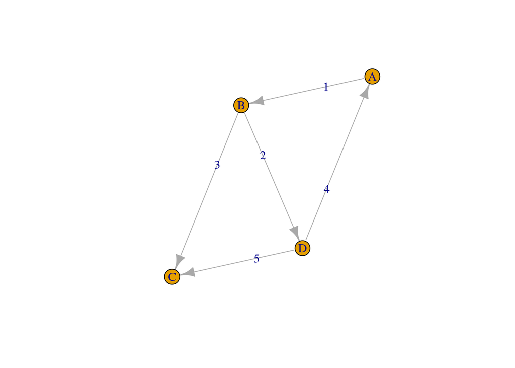

```r
library(igraph)
library(ggplot2)
g = igraph::graph_from_literal( A-+B, B-+D, B-+C, D-+A, D-+C)
plot(g,edge.label = c("1","2","3","4","5"))
```

The incidence matrix of this directed graph has n = 4 nodes and m = 5 edges.

```r
inc_mat = cbind(c(-1,1,0,0),c(0,1,0,-1),c(0,-1,1,0), c(1,0,0,-1), c(0,0,1,-1))
rownames(inc_mat) = c("A","B","C","D")
inc_mat
```

```
##   [,1] [,2] [,3] [,4] [,5]
## A   -1    0    0    1    0
## B    1    1   -1    0    0
## C    0    0    1    0    1
## D    0   -1    0   -1   -1
```

**Describe the entries of the Laplacian matrix**. The *degree of the node*, i.e. the number of edges that connect to it, is shown on the diagonal. The off-diagonal entries are the negative of the number of edges connecting that distinct pair of nodes.

$L_{ii}|{i \in 1..n} = degree\_of\_node\_i$

$L_{ij}|{i \neq j} = -\ distinct\_edges\_beween\_i\_and\_j$

```r
L = inc_mat %*% t(inc_mat)
L
```

```
##    A  B  C  D
## A  2 -1  0 -1
## B -1  3 -1 -1
## C  0 -1  2 -1
## D -1 -1 -1  3
```